# Zebrafish cranial neural crest

Nils Trost

Data from: [Fabian et al., Lifelong single-cell profiling of cranial neural crest diversification in zebrafish. Nat Commun 13, 13 (2022).](https://www.nature.com/articles/s41467-021-27594-w#Sec1).

# Integration of scRNA-seq and snATAC-seq datasets

## Load packages

```r
library(tidyverse)
library(Seurat)
library(Signac)
library(patchwork)
library(hexpression)
```

## Load data

### RNA

```r
rna_datasets_paths <- list(
  dpf1.5 = "data/RNA/1.5dpf_scRNA.rds",
  dpf2 = "data/RNA/2dpf_scRNA.rds",
  dpf3 = "data/RNA/3dpf_scRNA.rds",
  dpf5 = "data/RNA/5dpf_scRNA.rds",
  dpf14 = "data/RNA/14dpf_scRNA.rds",
  dpf60 = "data/RNA/60dpf_scRNA.rds",
  dpf150 = "data/RNA/150dpf_scRNA.rds"
)

rna_datasets <- lapply(rna_datasets_paths, readRDS)
```

### ATAC

```r
atac_datasets_paths <- list(
  dpf1.5 = "data/ATAC/1.5dpf_snATAC_SnapATAC.rds",
  dpf2 = "data/ATAC/2dpf_snATAC_SnapATAC.rds",
  dpf3 = "data/ATAC/3dpf_snATAC_SnapATAC.rds",
  dpf5 = "data/ATAC/5dpf_snATAC_SnapATAC.rds",
  dpf14 = "data/ATAC/14dpf_snATAC_SnapATAC.rds",
  dpf60 = "data/ATAC/60dpf_snATAC_SnapATAC.rds",
  dpf210 = "data/ATAC/210dpf_snATAC_SnapATAC.rds"
)

atac_datasets <- lapply(atac_datasets_paths, readRDS)
```

## Add annotation

The authors annotated the RNA dataset of 150 DPF (adult) zebrafish with cell types. I add the annotation to the 150dpf RNA object and then transfer it to the other datasets.

```r
annotation <- setNames(
  c(
    "stroma 1",
    "gill progenitor 1",
    "gill cartilage",
    "gill cartilage",
    "dermal fibroblast",
    "gill cartilage",
    "gill cartilage",
    "periosteum/tendon/ligament",
    "teeth",
    "perivascular",
    "pillar",
    "smooth muscle 2",
    "gill progenitor 2",
    "smooth muscle",
    "gill stroma",
    "cycling cells",
    "tunica media",
    "stroma 2",
    "hyaline cartilage",
    "bone"
  ),
  levels(droplevels(rna_datasets$dpf150$RNA_snn_res.0.8))
)

rna_datasets$dpf150$annotation <- as.factor(unname(
  annotation[as.character(rna_datasets$dpf150$RNA_snn_res.0.8)]
))
```

I plot the annotation to check if it looks correct.

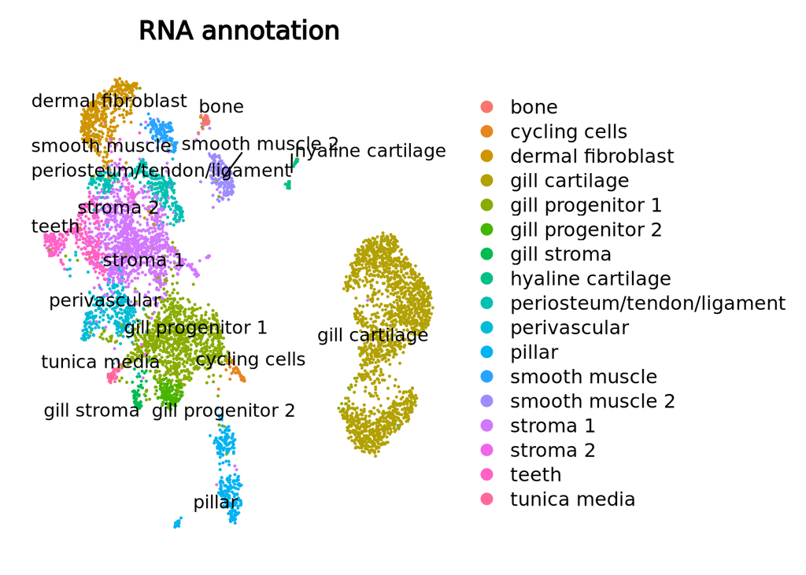

```r
DimPlot(rna_datasets$dpf150, group.by = "annotation", label = T, repel = T) +
  NoAxes() +
  ggtitle("RNA annotation")
```

### Transfer annotation to other datasets

I use the PCA transfer workflow as described in the [Seurat vignette](https://satijalab.org/seurat/articles/integration_mapping) to transfer the annotation from the 150 DPF RNA dataset to the other RNA datasets. The metadata of the objects then has a column `annotation` with the predicted label (highest prediction score). The prediction score of that label is called `prediction.score.max`. Additionally, the metadata contains columns with the prediction scores for each label.

```r
transfer_anno <- function(dataset) {
  transfer_anchors <- FindTransferAnchors(
    reference = rna_datasets$dpf150,
    query = dataset,
    features = VariableFeatures(rna_datasets$dpf150),
    reference.assay = "RNA",
    query.assay = "RNA"
  )
  predictions <- TransferData(
    anchorset = transfer_anchors,
    refdata = rna_datasets$dpf150$annotation,
    dims = 1:30
  )
  predictions <- predictions |>
    mutate(
      predicted.id = factor(
        predicted.id, levels = levels(rna_datasets$dpf150$annotation)
      )
    ) |>
    dplyr::rename(
      annotation = predicted.id
    )

  AddMetaData(
    dataset,
    metadata = predictions
  )
}
```

```r
rna_datasets[1:6] <- lapply(rna_datasets[1:6], transfer_anno)
```

```
## Performing PCA on the provided reference using 2000 features as input.
```

```
## Projecting cell embeddings
```

```
## Finding neighborhoods
```

```
## Finding anchors
```

```
##  Found 197 anchors
```

```
## Finding integration vectors
```

```
## Finding integration vector weights
```

```
## Predicting cell labels
```

```
## Performing PCA on the provided reference using 2000 features as input.
```

```
## Projecting cell embeddings
```

```
## Finding neighborhoods
```

```
## Finding anchors
```

```
##  Found 304 anchors
```

```
## Finding integration vectors
```

```
## Finding integration vector weights
```

```
## Predicting cell labels
```

```
## Performing PCA on the provided reference using 2000 features as input.
```

```
## Projecting cell embeddings
```

```
## Finding neighborhoods
```

```
## Finding anchors
```

```
##  Found 1909 anchors
```

```
## Finding integration vectors
```

```
## Finding integration vector weights
```

```
## Predicting cell labels
```

```
## Performing PCA on the provided reference using 2000 features as input.
```

```
## Projecting cell embeddings
```

```
## Finding neighborhoods
```

```
## Finding anchors
```

```
##  Found 4245 anchors
```

```
## Finding integration vectors
```

```
## Finding integration vector weights
```

```
## Predicting cell labels
```

```
## Performing PCA on the provided reference using 2000 features as input.
```

```
## Projecting cell embeddings
```

```
## Finding neighborhoods
```

```
## Finding anchors
```

```
##  Found 6698 anchors
```

```
## Finding integration vectors
```

```
## Finding integration vector weights
```

```
## Predicting cell labels
```

```
## Performing PCA on the provided reference using 2000 features as input.
```

```
## Projecting cell embeddings
```

```
## Finding neighborhoods
```

```
## Finding anchors
```

```
##  Found 6459 anchors
```

```
## Finding integration vectors
```

```
## Finding integration vector weights
```

```
## Predicting cell labels
```

I plot the annotation for all RNA datasets to check if it looks correct.

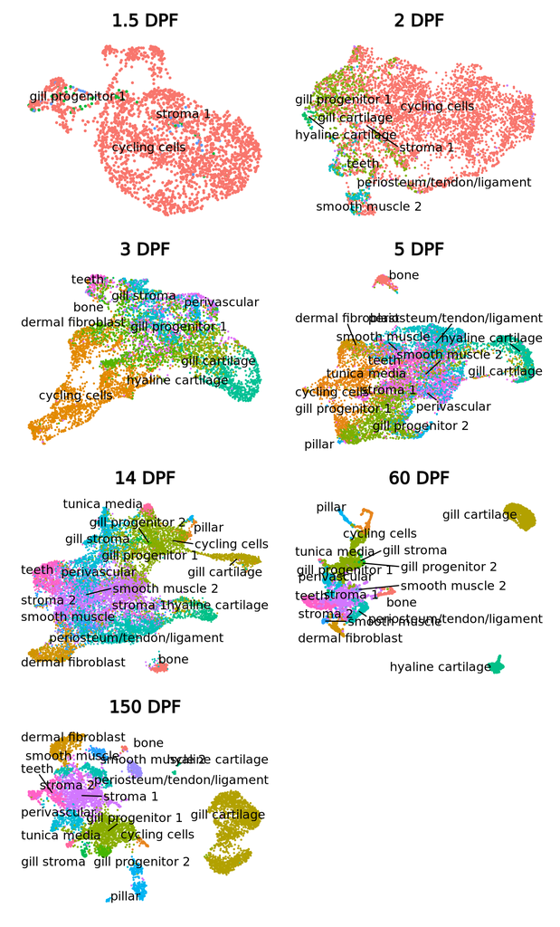

```r
(DimPlot(rna_datasets$dpf1.5, group.by = "annotation", label = T, repel = T) + NoAxes() + NoLegend() + ggtitle("1.5 DPF")) +
  (DimPlot(rna_datasets$dpf2, group.by = "annotation", label = T, repel = T) + NoAxes() + NoLegend() + ggtitle("2 DPF")) +
  (DimPlot(rna_datasets$dpf3, group.by = "annotation", label = T, repel = T) + NoAxes() + NoLegend() + ggtitle("3 DPF")) +
  (DimPlot(rna_datasets$dpf5, group.by = "annotation", label = T, repel = T) + NoAxes() + NoLegend() + ggtitle("5 DPF")) +
  (DimPlot(rna_datasets$dpf14, group.by = "annotation", label = T, repel = T) + NoAxes() + NoLegend() + ggtitle("14 DPF")) +
  (DimPlot(rna_datasets$dpf60, group.by = "annotation", label = T, repel = T) + NoAxes() + NoLegend() + ggtitle("60 DPF")) +
  (DimPlot(rna_datasets$dpf150, group.by = "annotation", label = T, repel = T) + NoAxes() + NoLegend() + ggtitle("150 DPF")) +
  plot_layout(ncol = 2)
```

```r
ggsave("figures/RNA_annotation.pdf")
```

The early stages are dominated by cycling cells. We should check if this is expected. There is not much information about this in this paper, the earlier samples are just annotated as mesenchyme. In later stages, more defined cell types appear and the annotation looks reasonable.

We should still take some time to check with literature marker genes.

## Transfer annotation and clusters to RNA to ATAC

Now, I will transfer the annotation and clusters from the RNA datasets to the ATAC datasets. I will use the CCA transfer workflow as described in the [Seurat vignette](https://satijalab.org/seurat/articles/seurat5_atacseq_integration_vignette). I first try it with the clusters of the 1.5 DPF RNA dataset, to test if it works.

```r
transfer_anchors <- FindTransferAnchors(
  reference = rna_datasets$dpf1.5,
  query = atac_datasets$dpf1.5,
  features = VariableFeatures(rna_datasets$dpf1.5),
  reference.assay = "RNA",
  query.assay = "ACTIVITY",
  reduction = "cca"
)
```

```
## Running CCA
```

```
## Merging objects
```

```
## Finding neighborhoods
```

```
## Finding anchors
```

```
##  Found 4529 anchors
```

```r
cluster_predictions <- TransferData(
  anchorset = transfer_anchors,
  refdata = rna_datasets$dpf1.5$RNA_snn_res.0.8,
  weight.reduction = atac_datasets$dpf1.5[["lsi"]],
  dims = 2:30
)
```

```
## Finding integration vectors
```

```
## Finding integration vector weights
```

```
## Predicting cell labels
```

```r
dpf1.5_test <- AddMetaData(
  atac_datasets$dpf1.5,
  metadata = cluster_predictions
)
dpf1.5_test$predicted.id <- factor(
  dpf1.5_test$predicted.id,
  levels = c("0", "1", "2", "4", "6", "7", "9", "10")
)
```

I plot the clusters and the expression/gene activity score of some marker genes that are specific for these clusters to check if the transfer result looks reasonable.

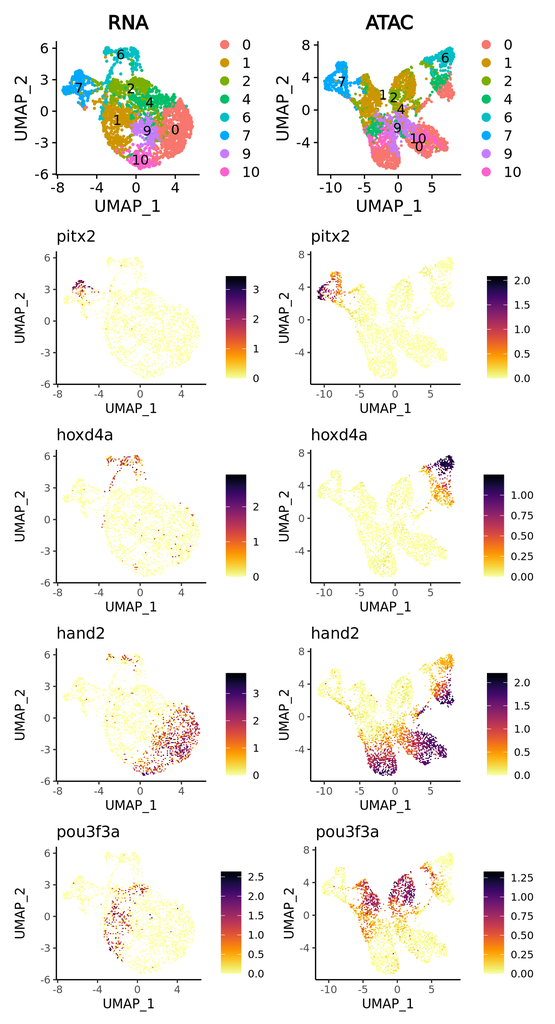

```r
(
  DimPlot(rna_datasets$dpf1.5, group.by = "RNA_snn_res.0.8", label = T) +
    ggtitle("RNA") |
    DimPlot(dpf1.5_test, group.by = "predicted.id", label = T) +
    ggtitle("ATAC")
) /
  (
    HexPlot(rna_datasets$dpf1.5, "pitx2", bins = 100) |
      HexPlot(dpf1.5_test, "pitx2", bins = 100)
  ) /
  (
    HexPlot(rna_datasets$dpf1.5, "hoxd4a", bins = 100) |
      HexPlot(dpf1.5_test, "hoxd4a", bins = 100)
  ) /
  (
    HexPlot(rna_datasets$dpf1.5, "hand2", bins = 100) |
      HexPlot(dpf1.5_test, "hand2", bins = 100)
  ) /
  (
    HexPlot(rna_datasets$dpf1.5, "pou3f3a", bins = 100) |
      HexPlot(dpf1.5_test, "pou3f3a", bins = 100)
  )
```

```r
ggsave("figures/RNA_ATAC_integration_1.5dpf_expression_activity.pdf")
```

This looks reasonable. I now transfer the annotation and the clusters pairwise from each RNA dataset to the corresponding ATAC dataset.

Similar to the annotation transfer in the RNA, the metadata of the objects then has a column `annotation` with the predicted label (highest prediction score) and a column `RNA_cluster` with the predicted cluster from the RNA data. The prediction scores of these labels are called `annotation_prediction.score.max` and `RNA_cluster_prediction.score.max`, respectively. Additionally, the metadata contains columns with the prediction scores for each label.

```r
transfer_anno_to_ATAC <- function(dataset_atac, dataset_rna) {
  transfer_anchors <- FindTransferAnchors(
    reference = dataset_rna,
    query = dataset_atac,
    features = VariableFeatures(dataset_rna),
    reference.assay = "RNA",
    query.assay = "ACTIVITY",
    reduction = "cca"
  )
  cluster_predictions <- TransferData(
    anchorset = transfer_anchors,
    refdata = dataset_rna$RNA_snn_res.0.8,
    weight.reduction = dataset_atac[["lsi"]],
    dims = 2:30
  ) |>
    mutate(
      predicted.id = factor(
        predicted.id, levels = levels(dataset_rna$RNA_snn_res.0.8)
      )
    ) |>
    dplyr::rename(
      RNA_cluster = predicted.id
    ) |>
    dplyr::rename_with(
      .fn = function(x) sub("prediction", "RNA_cluster_prediction", x)
    )
  annotation_predictions <- TransferData(
    anchorset = transfer_anchors,
    refdata = dataset_rna$annotation,
    weight.reduction = dataset_atac[["lsi"]],
    dims = 2:30
  ) |>
    mutate(
      predicted.id = factor(
        predicted.id, levels = levels(dataset_rna$annotation)
      )
    ) |>
    dplyr::rename(
      annotation = predicted.id
    ) |>
    dplyr::rename_with(
      .fn = function(x) sub("prediction", "annotation_prediction", x)
    )
  dataset_atac <- AddMetaData(
    dataset_atac,
    metadata = cluster_predictions
  )
  dataset_atac <- AddMetaData(
    dataset_atac,
    metadata = annotation_predictions
  )
  dataset_atac
}
```

```r
atac_datasets <- Map(transfer_anno_to_ATAC, atac_datasets, rna_datasets)
```

```
## Running CCA
```

```
## Merging objects
```

```
## Finding neighborhoods
```

```
## Finding anchors
```

```
##  Found 4529 anchors
```

```
## Finding integration vectors
```

```
## Finding integration vector weights
```

```
## Predicting cell labels
```

```
## Finding integration vectors
```

```
## Finding integration vector weights
```

```
## Predicting cell labels
```

```
## Running CCA
```

```
## Merging objects
```

```
## Finding neighborhoods
```

```
## Finding anchors
```

```
##  Found 6963 anchors
```

```
## Finding integration vectors
```

```
## Finding integration vector weights
```

```
## Predicting cell labels
```

```
## Finding integration vectors
```

```
## Finding integration vector weights
```

```
## Predicting cell labels
```

```
## Running CCA
```

```
## Merging objects
```

```
## Finding neighborhoods
```

```
## Finding anchors
```

```
##  Found 7208 anchors
```

```
## Finding integration vectors
```

```
## Finding integration vector weights
```

```
## Predicting cell labels
```

```
## Finding integration vectors
```

```
## Finding integration vector weights
```

```
## Predicting cell labels
```

```
## Running CCA
```

```
## Merging objects
```

```
## Finding neighborhoods
```

```
## Finding anchors
```

```
##  Found 6387 anchors
```

```
## Finding integration vectors
```

```
## Finding integration vector weights
```

```
## Predicting cell labels
```

```
## Finding integration vectors
```

```
## Finding integration vector weights
```

```
## Predicting cell labels
```

```
## Running CCA
```

```
## Merging objects
```

```
## Finding neighborhoods
```

```
## Finding anchors
```

```
##  Found 9741 anchors
```

```
## Finding integration vectors
```

```
## Finding integration vector weights
```

```
## Predicting cell labels
```

```
## Finding integration vectors
```

```
## Finding integration vector weights
```

```
## Predicting cell labels
```

```
## Running CCA
```

```
## Merging objects
```

```
## Finding neighborhoods
```

```
## Finding anchors
```

```
##  Found 3782 anchors
```

```
## Finding integration vectors
```

```
## Finding integration vector weights
```

```
## Predicting cell labels
```

```
## Finding integration vectors
```

```
## Finding integration vector weights
```

```
## Predicting cell labels
```

```
## Running CCA
```

```
## Merging objects
```

```
## Finding neighborhoods
```

```
## Finding anchors
```

```
##  Found 4410 anchors
```

```
## Finding integration vectors
```

```
## Finding integration vector weights
```

```
## Predicting cell labels
```

```
## Finding integration vectors
```

```
## Finding integration vector weights
```

```
## Predicting cell labels
```

I plot the results for all datasets to check if the transfer worked well.

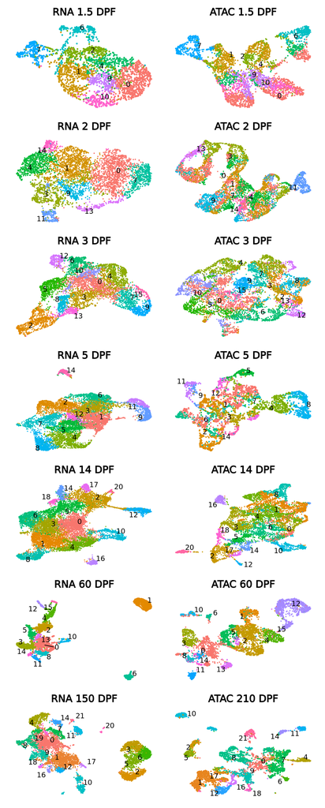

```r
(DimPlot(rna_datasets$dpf1.5, group.by = "RNA_snn_res.0.8", label = T, repel = T) + NoAxes() + NoLegend() + ggtitle("RNA 1.5 DPF")) +
  (DimPlot(atac_datasets$dpf1.5, group.by = "RNA_cluster", label = T, repel = T) + NoAxes() + NoLegend() + ggtitle("ATAC 1.5 DPF")) +
  (DimPlot(rna_datasets$dpf2, group.by = "RNA_snn_res.0.8", label = T, repel = T) + NoAxes() + NoLegend() + ggtitle("RNA 2 DPF")) +
  (DimPlot(atac_datasets$dpf2, group.by = "RNA_cluster", label = T, repel = T) + NoAxes() + NoLegend() + ggtitle("ATAC 2 DPF")) +
  (DimPlot(rna_datasets$dpf3, group.by = "RNA_snn_res.0.8", label = T, repel = T) + NoAxes() + NoLegend() + ggtitle("RNA 3 DPF")) +
  (DimPlot(atac_datasets$dpf3, group.by = "RNA_cluster", label = T, repel = T) + NoAxes() + NoLegend() + ggtitle("ATAC 3 DPF")) +
  (DimPlot(rna_datasets$dpf5, group.by = "RNA_snn_res.0.8", label = T, repel = T) + NoAxes() + NoLegend() + ggtitle("RNA 5 DPF")) +
  (DimPlot(atac_datasets$dpf5, group.by = "RNA_cluster", label = T, repel = T) + NoAxes() + NoLegend() + ggtitle("ATAC 5 DPF")) +
  (DimPlot(rna_datasets$dpf14, group.by = "RNA_snn_res.0.8", label = T, repel = T) + NoAxes() + NoLegend() + ggtitle("RNA 14 DPF")) +
  (DimPlot(atac_datasets$dpf14, group.by = "RNA_cluster", label = T, repel = T) + NoAxes() + NoLegend() + ggtitle("ATAC 14 DPF")) +
  (DimPlot(rna_datasets$dpf60, group.by = "RNA_snn_res.0.8", label = T, repel = T) + NoAxes() + NoLegend() + ggtitle("RNA 60 DPF")) +
  (DimPlot(atac_datasets$dpf60, group.by = "RNA_cluster", label = T, repel = T) + NoAxes() + NoLegend() + ggtitle("ATAC 60 DPF")) +
  (DimPlot(rna_datasets$dpf150, group.by = "RNA_snn_res.0.8", label = T, repel = T) + NoAxes() + NoLegend() + ggtitle("RNA 150 DPF")) +
  (DimPlot(atac_datasets$dpf210, group.by = "RNA_cluster", label = T, repel = T) + NoAxes() + NoLegend() + ggtitle("ATAC 210 DPF")) +
  plot_layout(ncol = 2)
```

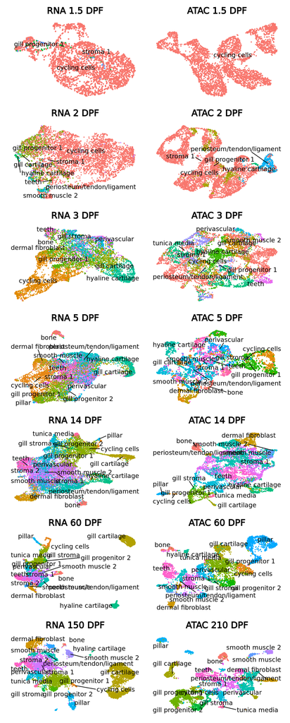

```r
ggsave("figures/RNA_ATAC_integration_clusters.pdf")
(DimPlot(rna_datasets$dpf1.5, group.by = "annotation", label = T, repel = T) + NoAxes() + NoLegend() + ggtitle("RNA 1.5 DPF")) +
  (DimPlot(atac_datasets$dpf1.5, group.by = "annotation", label = T, repel = T) + NoAxes() + NoLegend() + ggtitle("ATAC 1.5 DPF")) +
  (DimPlot(rna_datasets$dpf2, group.by = "annotation", label = T, repel = T) + NoAxes() + NoLegend() + ggtitle("RNA 2 DPF")) +
  (DimPlot(atac_datasets$dpf2, group.by = "annotation", label = T, repel = T) + NoAxes() + NoLegend() + ggtitle("ATAC 2 DPF")) +
  (DimPlot(rna_datasets$dpf3, group.by = "annotation", label = T, repel = T) + NoAxes() + NoLegend() + ggtitle("RNA 3 DPF")) +
  (DimPlot(atac_datasets$dpf3, group.by = "annotation", label = T, repel = T) + NoAxes() + NoLegend() + ggtitle("ATAC 3 DPF")) +
  (DimPlot(rna_datasets$dpf5, group.by = "annotation", label = T, repel = T) + NoAxes() + NoLegend() + ggtitle("RNA 5 DPF")) +
  (DimPlot(atac_datasets$dpf5, group.by = "annotation", label = T, repel = T) + NoAxes() + NoLegend() + ggtitle("ATAC 5 DPF")) +
  (DimPlot(rna_datasets$dpf14, group.by = "annotation", label = T, repel = T) + NoAxes() + NoLegend() + ggtitle("RNA 14 DPF")) +
  (DimPlot(atac_datasets$dpf14, group.by = "annotation", label = T, repel = T) + NoAxes() + NoLegend() + ggtitle("ATAC 14 DPF")) +
  (DimPlot(rna_datasets$dpf60, group.by = "annotation", label = T, repel = T) + NoAxes() + NoLegend() + ggtitle("RNA 60 DPF")) +
  (DimPlot(atac_datasets$dpf60, group.by = "annotation", label = T, repel = T) + NoAxes() + NoLegend() + ggtitle("ATAC 60 DPF")) +
  (DimPlot(rna_datasets$dpf150, group.by = "annotation", label = T, repel = T) + NoAxes() + NoLegend() + ggtitle("RNA 150 DPF")) +
  (DimPlot(atac_datasets$dpf210, group.by = "annotation", label = T, repel = T) + NoAxes() + NoLegend() + ggtitle("ATAC 210 DPF")) +
  plot_layout(ncol = 2)
```

```r
ggsave("figures/RNA_ATAC_integration_annotation.pdf")
```

# Save the results

## Seurat objects

I save the Seurat objects as lists of objects, for the RNA and ATAC datasets, respectively.

```r
saveRDS(rna_datasets, "saved_data/rna_datasets_list.rds")
saveRDS(atac_datasets, "saved_data/atac_datasets_list.rds")
```

## Metadata

I export the metadata of the RNA and ATAC datasets as TSV files, with the cell names as first column. The metadata contains the (transferred) annotation and the original clusters (`RNA_snn_res.0.8`) for the RNA datasets, and the transferred annotation and RNA clusters for the ATAC datasets.

```r
walk(names(rna_datasets), function(name) {
  write.table(
    rna_datasets[[name]]@meta.data |>
      rownames_to_column(var = "cell"),
    file = paste0("saved_data/rna_", name, "_metadata.tsv"),
    sep = "\t",
    quote = F,
    row.names = F
  )
})

walk(names(atac_datasets), function(name) {
  write.table(
    atac_datasets[[name]]@meta.data |>
      rownames_to_column(var = "cell"),
    file = paste0("saved_data/atac_", name, "_metadata.tsv"),
    sep = "\t",
    quote = F,
    row.names = F
  )
})
```